# The importance of the iNaturalist network

Meeting: Evolving the iNat network discussion

Florencia Grattarola

2025-07-01

## The Network

Although the platform continues to grow globally, the contributions and progress of its network remain understudied. Here we show the collective progress of the network through numbers, and reveal that countries with a local iNaturalist site differ from the global average.

## Methods

We tested different variables to assess what drives the countries’ numbers on iNat. Indicators per country were extracted using the WDI: World Development Indicators (World Bank) on the **23rd of May, 2025**.

| Response variables |
| --- |
| `n_records_inat`: total number of records on iNaturalist per country |
| `n_records_gbif_iNat`: number of records from iNaturalist on GBIF per country (proxy for quality, research grade records) |
| `n_users`: number of users recording in the country (this is not exactly the users from the country, but users that have generated records in the country) |

| Explanatory variables |
| --- |
| `pop`: population of the country (*SP.POP.TOTL*) |
| `area`: area of the country in km<sup>2</sup> (*AG.SRF.TOTL.K2*) |
| `latitude`: country’s centroid latitude (as a proxy of expected biodiversity) |
| `gdp`: GDP per capita (*NY.GDP.PCAP.CD*) |
| `gdp_research`: % of the GDP of the country dedicated to research (*GB.XPD.RSDV.GD.ZS*) |

## Associations

### Population

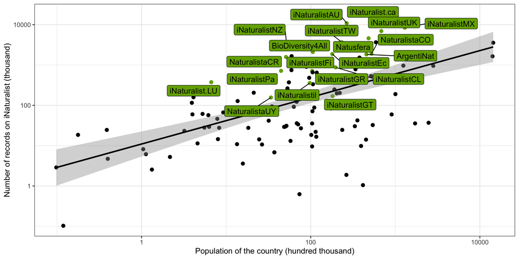

Number of records on iNaturalist vs Population of the country

## Associations

### Population

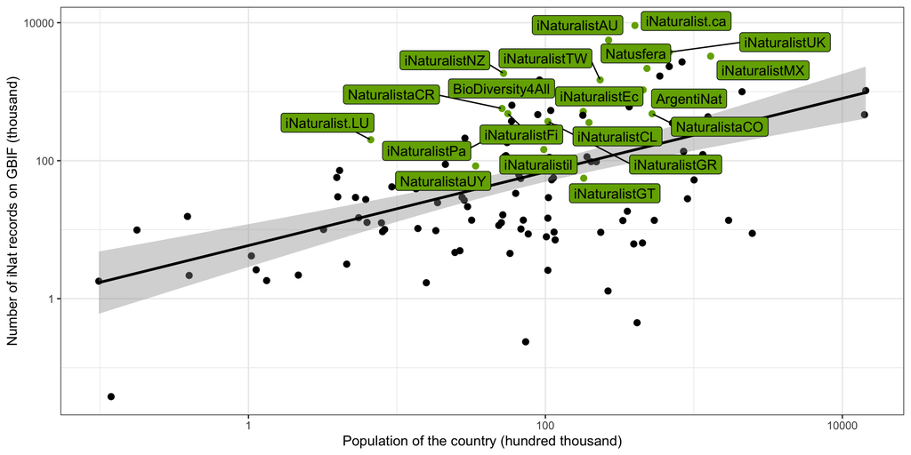

Number of iNat records on GBIF vs Population of the country

## Associations

### Population

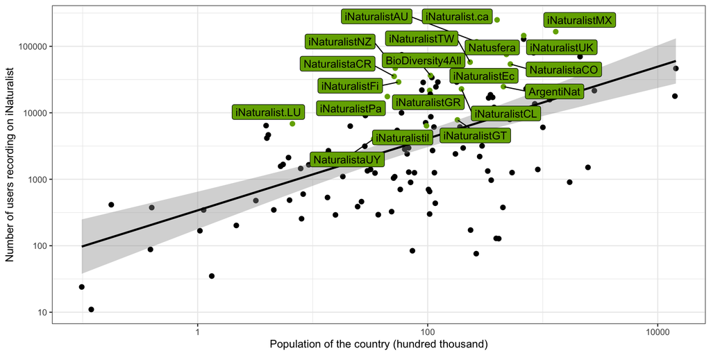

Number of users recording on iNaturalist vs Population of the country

## Associations

### Area of the country in km<sup>2</sup>

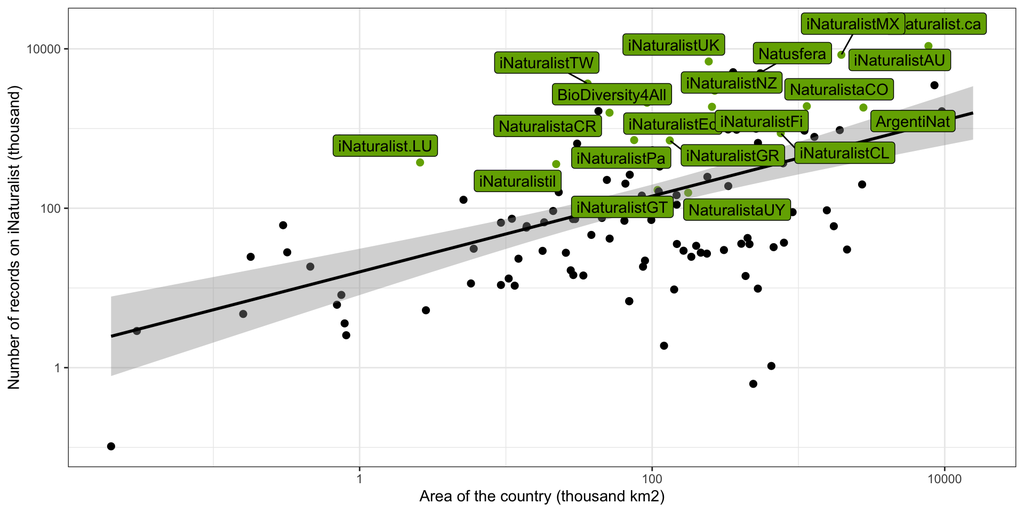

Number of records on iNaturalist vs Area of the country

## Associations

### Area of the country in km<sup>2</sup>

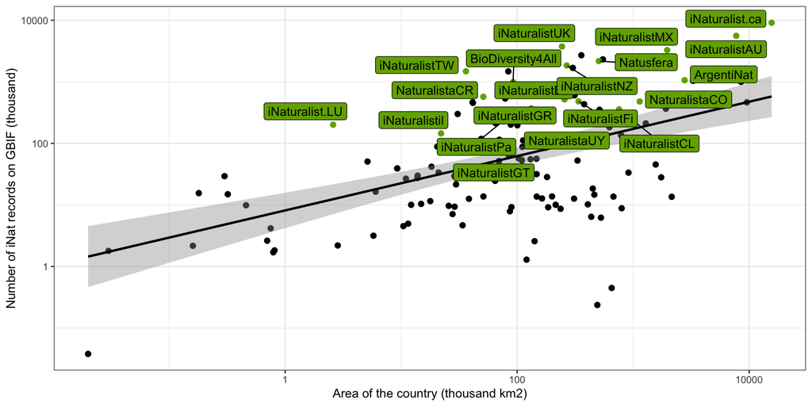

Number of iNat records on GBIF vs Area of the country

## Associations

### Area of the country in km<sup>2</sup>

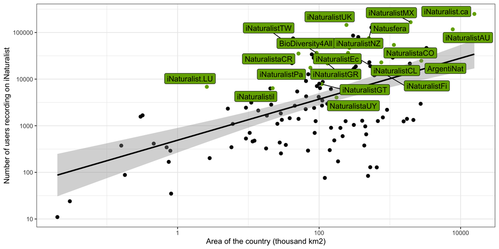

Number of users recording on iNaturalist vs Area of the country

## Associations

### Country’s centroid latitude

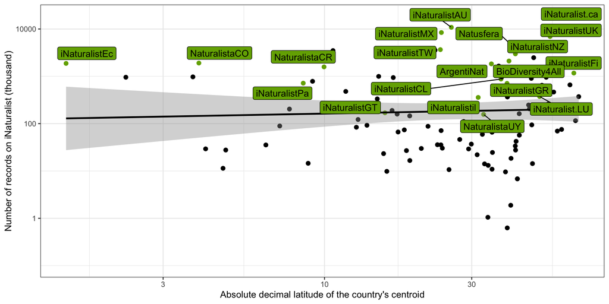

Number of records on iNaturalist vs country’s centroid latitude

## Associations

### Country’s centroid latitude

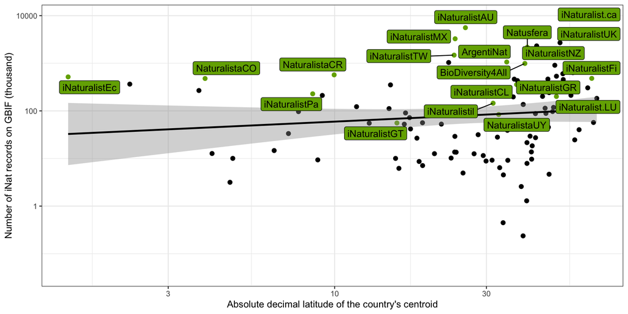

Number of iNat records on GBIF vs country’s centroid latitude

## Associations

### Country’s centroid latitude

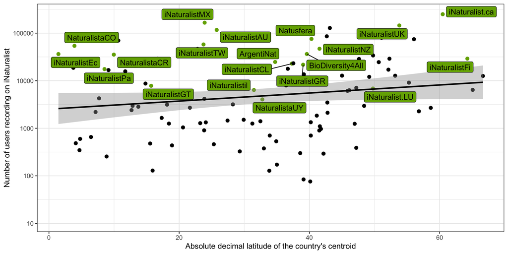

Number of users recording on iNaturalist vs country’s centroid latitude

## Associations

### GDP per capita

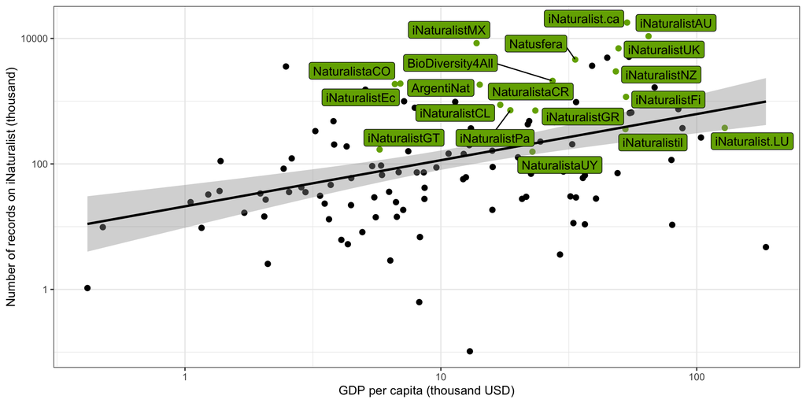

Number of records on iNaturalist vs country’s GDP per capita

## Associations

### GDP per capita

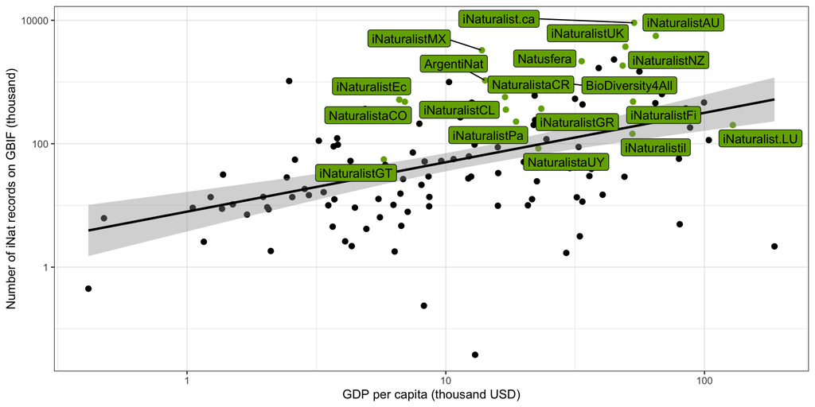

Number of iNat records on GBIF vs country’s GDP per capita

## Associations

### GDP per capita

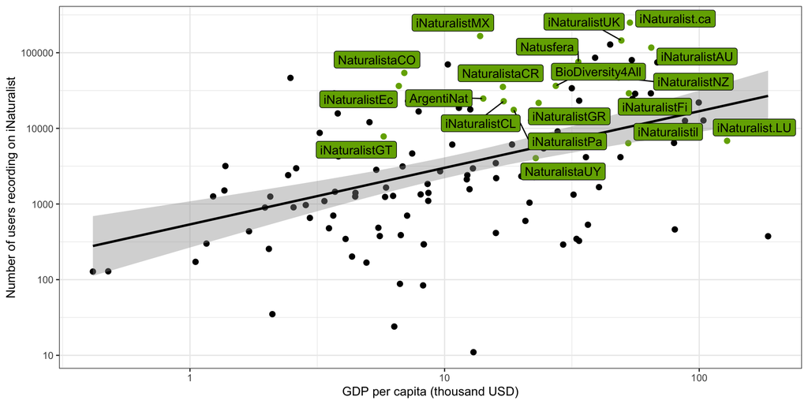

Number of users recording on iNaturalist vs GDP per capita

## Associations

### % of the GDP of the country dedicated to research

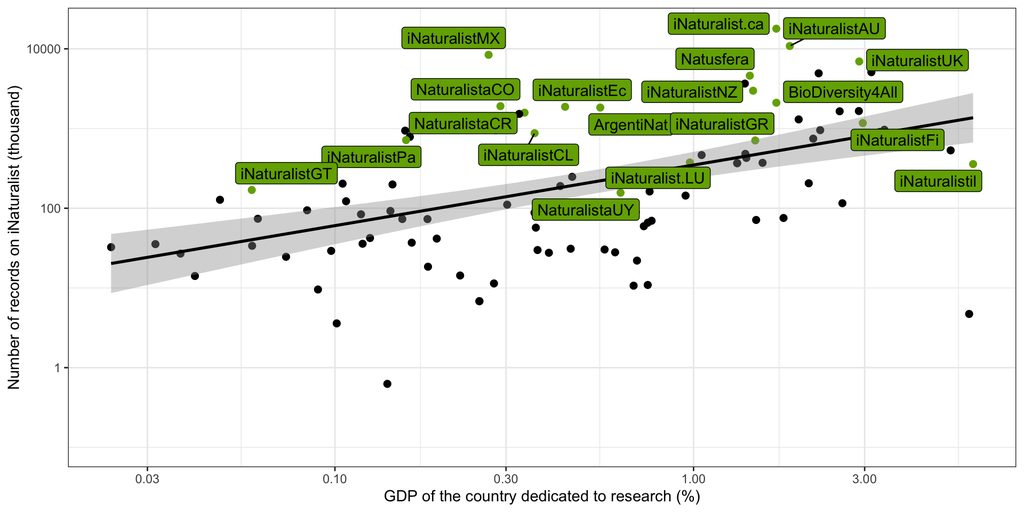

Number of records on iNaturalist vs % of the country’s GDP dedicated to research

## Associations

### % of the GDP of the country dedicated to research

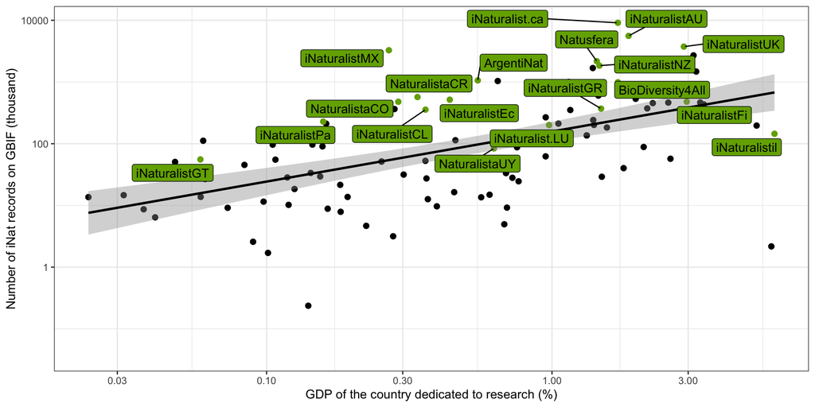

Number of iNat records on GBIF vs % of the country’s GDP dedicated to research

## Associations

### % of the GDP of the country dedicated to research

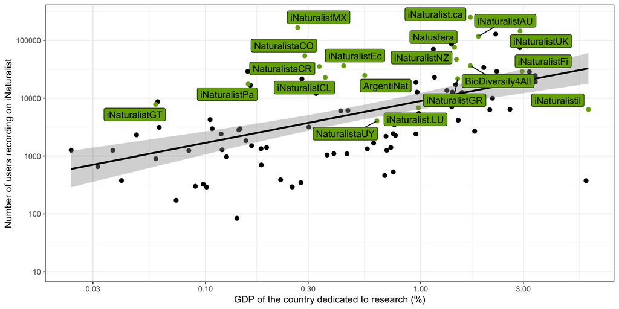

Number of users recording on iNaturalist vs % of the country’s GDP dedicated to research

## Models

We used the variables in logarithmic scale

| Country | Number of records on iNat | Number of iNat records on GBIF | Number of users recording | Area of the country in km2 | Population | GDP per capita | % of the GDP of the country dedicated to research | Country’s centroid latitude |
| --- | --- | --- | --- | --- | --- | --- | --- | --- |
| CA | 17900009 | 9108780 | 249842 | 15634410 | 40097761 | 53431.1857063879 | 1.70132994651794 | 60.4767577517481 |
| MX | 8412995 | 3270340 | 166175 | 1964375 | 129739759 | 13790.0243428344 | 0.268189996480942 | 23.9134526666434 |
| CR | 1580872 | 570713 | 35332 | 51100 | 5105525 | 16942.0268119375 | 0.33788999915123 | 9.96546183349417 |
| CO | 1907160 | 478707 | 54068 | 1140619.05 | 52321152 | 6947.35928681966 | 0.289400011301041 | 3.91689009181808 |
| AR | 1833740 | 1061747 | 24765 | 2780400 | 45538401 | 14187.4827252965 | 0.549470007419586 | -34.7368322240771 |
| EC | 1874438 | 517241 | 36348 | 256370 | 17980083 | 6609.80408154957 | 0.438389986753464 | -1.45418251758746 |
| PA | 716270 | 228190 | 17553 | 75320 | 4458759 | 18686.4050961265 | 0.157910004258156 | 8.53276828861842 |
| CL | 874666 | 356566 | 22833 | 756700 | 19658835 | 17067.8136150601 | 0.360410004854202 | -37.3088721040861 |
| GT | 169504 | 55673 | 7816 | 108890 | 18124838 | 5762.82174615918 | 0.0586300007998943 | 15.6955465342213 |
| UY | 156551 | 83919 | 4041 | 176220 | 3388081 | 22797.8111731861 | 0.625919997692108 | -32.7738232115978 |

[output cut: 9 more lines]

## Models

We found that the presence of a national iNaturalist hub was a highly significant positive factor in all three models.

## Models: GLM

### Total number of records on iNaturalist per country

```r
fit_n_records <- lm(log_n_records_inat ~ log_area + log_gdp + gdp_research + log_pop + latitude + has_site, data=data_regressions)
step_n_records <- stepAIC(fit_n_records, direction = 'both', trace=F)
step_n_records$anova
```

```
Stepwise Model Path
Analysis of Deviance Table

Initial Model:
log_n_records_inat ~ log_area + log_gdp + gdp_research + log_pop +
    latitude + has_site

Final Model:
log_n_records_inat ~ log_gdp + log_pop + has_site

            Step Df  Deviance Resid. Df Resid. Dev      AIC
1                                    89   144.0720 52.97261
2     - latitude  1 0.1880533        90   144.2600 51.09784
3     - log_area  1 1.5337988        91   145.7938 50.11314
4 - gdp_research  1 2.7002138        92   148.4940 49.87487
```

## Models: GLM

### Total number of records on iNaturalist per country

```
Call:
lm(formula = log_n_records_inat ~ log_gdp + log_pop + has_site,
    data = data_regressions)

Residuals:
    Min      1Q  Median      3Q     Max
-4.7656 -0.5855  0.2470  0.8829  2.7961

Coefficients:
            Estimate Std. Error t value          Pr(>|t|)
(Intercept) -7.55971    2.07547  -3.642          0.000446 ***
log_gdp      0.77737    0.12124   6.412 0.000000006090501 ***
log_pop      0.74348    0.08666   8.579 0.000000000000222 ***
has_site1    1.70075    0.33768   5.037 0.000002350212033 ***
---
Signif. codes:  0 '***' 0.001 '**' 0.01 '*' 0.05 '.' 0.1 ' ' 1

Residual standard error: 1.27 on 92 degrees of freedom
Multiple R-squared:  0.6057,    Adjusted R-squared:  0.5929
F-statistic: 47.11 on 3 and 92 DF,  p-value: < 0.00000000000000022
```

## Models: GLM

### Number of records from iNaturalist on GBIF per country

```r
fit_gbif <- lm(log_n_gbif_inat ~ log_area + log_gdp + gdp_research + log_pop + latitude + has_site, data=data_regressions)
step_gbif <- stepAIC(fit_gbif, direction = 'both', trace = F)
step_gbif$anova
```

```
Stepwise Model Path
Analysis of Deviance Table

Initial Model:
log_n_gbif_inat ~ log_area + log_gdp + gdp_research + log_pop +
    latitude + has_site

Final Model:
log_n_gbif_inat ~ log_gdp + log_pop + has_site

            Step Df  Deviance Resid. Df Resid. Dev      AIC
1                                    89   137.5124 48.49911
2     - latitude  1 0.1754503        90   137.6878 46.62151
3     - log_area  1 1.2131426        91   138.9010 45.46365
4 - gdp_research  1 1.8551255        92   140.7561 44.73731
```

## Models: GLM

### Number of records from iNaturalist on GBIF per country

```
Call:
lm(formula = log_n_gbif_inat ~ log_gdp + log_pop + has_site,
    data = data_regressions)

Residuals:
    Min      1Q  Median      3Q     Max
-4.9165 -0.6325  0.1923  0.8941  2.6572

Coefficients:
            Estimate Std. Error t value         Pr(>|t|)
(Intercept) -8.05617    2.02067  -3.987         0.000134 ***
log_gdp      0.86738    0.11804   7.348 0.00000000007977 ***
log_pop      0.67166    0.08437   7.961 0.00000000000435 ***
has_site1    1.62863    0.32876   4.954 0.00000329279982 ***
---
Signif. codes:  0 '***' 0.001 '**' 0.01 '*' 0.05 '.' 0.1 ' ' 1

Residual standard error: 1.237 on 92 degrees of freedom
Multiple R-squared:  0.6104,    Adjusted R-squared:  0.5977
F-statistic: 48.04 on 3 and 92 DF,  p-value: < 0.00000000000000022
```

## Models: GLM

### Number of users recording in the country

```r
fit_users <- lm(log_n_users ~ log_area + log_gdp + gdp_research + log_pop + latitude + has_site, data=data_regressions)
step_users <- stepAIC(fit_users, direction = 'both', trace = F)
step_users$anova
```

```
Stepwise Model Path
Analysis of Deviance Table

Initial Model:
log_n_users ~ log_area + log_gdp + gdp_research + log_pop + latitude +
    has_site

Final Model:
log_n_users ~ log_gdp + log_pop + has_site

            Step Df  Deviance Resid. Df Resid. Dev      AIC
1                                    89   116.7371 32.77534
2     - latitude  1 0.2131326        90   116.9503 30.95046
3     - log_area  1 0.8075393        91   117.7578 29.61106
4 - gdp_research  1 1.4958103        92   119.2536 28.82281
```

## Models: GLM

### Number of users recording in the country

```
Call:
lm(formula = log_n_users ~ log_gdp + log_pop + has_site, data = data_regressions)

Residuals:
    Min      1Q  Median      3Q     Max
-3.2300 -0.6679  0.1887  0.7349  2.8989

Coefficients:
            Estimate Std. Error t value        Pr(>|t|)
(Intercept) -9.32735    1.85993  -5.015 0.0000025686096 ***
log_gdp      0.76108    0.10865   7.005 0.0000000003985 ***
log_pop      0.64041    0.07766   8.246 0.0000000000011 ***
has_site1    1.44701    0.30261   4.782 0.0000065761626 ***
---
Signif. codes:  0 '***' 0.001 '**' 0.01 '*' 0.05 '.' 0.1 ' ' 1

Residual standard error: 1.139 on 92 degrees of freedom
Multiple R-squared:  0.6043,    Adjusted R-squared:  0.5914
F-statistic: 46.83 on 3 and 92 DF,  p-value: < 0.00000000000000022
```

## Models: Random Forest

### Total number of records on iNaturalist per country

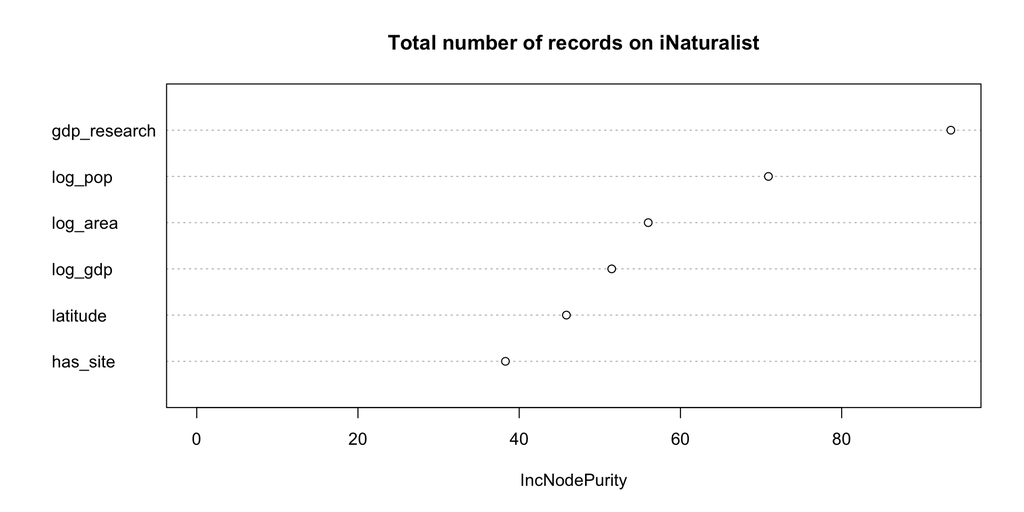

## Models: Random Forest

### Number of records from iNaturalist on GBIF per country

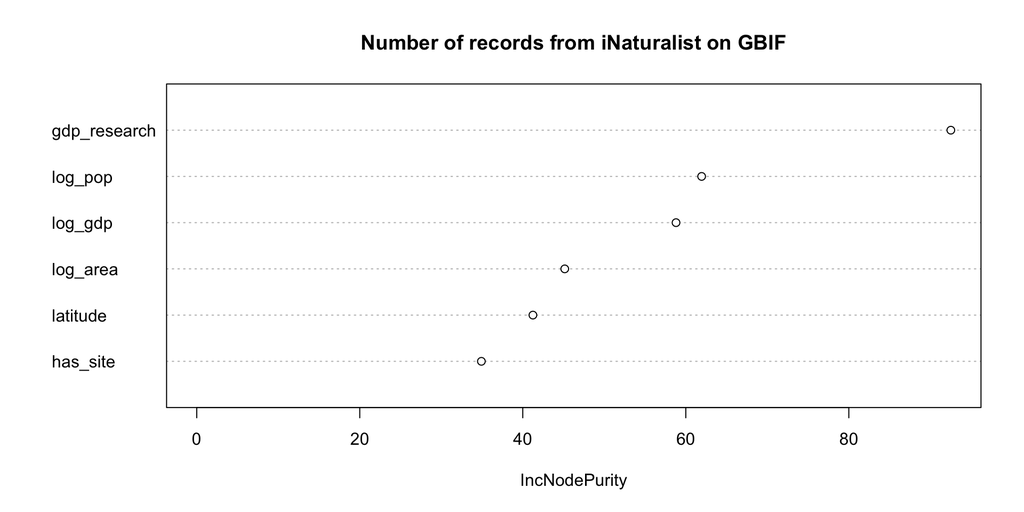

## Models: Random Forest

### Number of users recording in the country

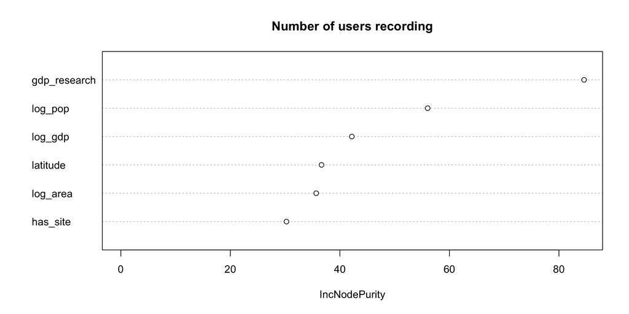

## Conclusions

Since users often engage beyond national borders, e.g., through identifications, taxon curation, and travel, our results suggest that the efforts of the network have contributed significantly to iNaturalist’s global success beyond the United States. Our findings also highlight the value of localised strategies within global citizen science platforms.